# Exercise 1: R markdown, automating tasks, FASTA/FASTQ/string processing

# Question 1

Familiarize yourself with how to make an *executable document* that mixes text, R code, R output and graphics using R markdown.

Exercises for the Robinson section are to be handed in in HTML format. The exercises will only be accepted if the filenames are named systematically: lastname_firstname_exerciseX or lastname_firstname_exerciseX_questionY (e.g., robinson_mark_exercise1.html, robinson_mark_exercise1_question1.html); an easy way to do this is to name your RMD accordingly (e.g., robinson_mark_exercise1.rmd). A link to upload the exercises will be provided. As mentioned in the Introduction, this allows for us to collect attendance / participation, but is primarily for us to identify pitfalls or potential improvements in the submitted R code.

In addition, we recommend that you organize your work for this section (and in general!) in a systematic way. For example you could create a `robinson_exercises` folder in the `/Users/username` (or `/Volumes/UsersBio/username`) directory on the Mac computers in the course room. Within this directory, you could create subdirectories `ex1`, `ex2`, .., `ex5` for the 5 exercises. If possible, pick a systematic organized way from the start and stick to it (you can always adjust the *system* later).

# Question 2

Repeat the following (von Mering) Unix exercise from within R using the *Biostrings* package:

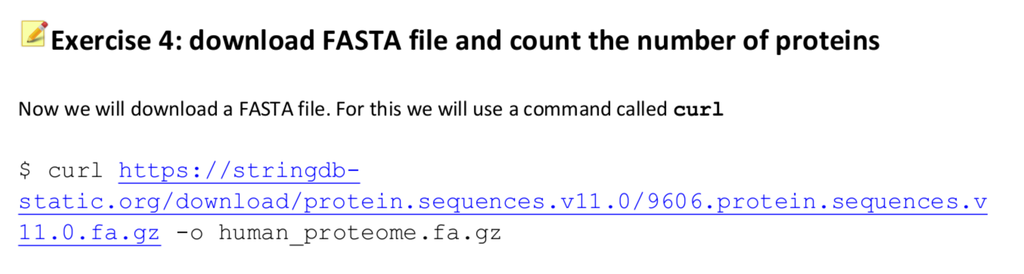

*Hint:* Use `readAAStringSet()` to read protein sequences from FASTA files.

```r
f <- "https://stringdb-static.org/download/protein.sequences.v11.0/9606.protein.sequences.v11.0.fa.gz"
```

In addition to counting the number of proteins:

1. generate a histogram of the distribution of protein lengths (you may prefer logarithm of the length). See plot below.
2. make a table (e.g., data.frame) with three columns: Ensembl protein identifier (e.g., ENSP00000323032), number of amino acids in the protein (width of the sequence), and number of prolines in each protein (letter P).
3. Write this table into a tab-delimited file called `human_protein_lengths.txt`

*Hints:*

- To access the elements/information in the `AAStringSet` you need to use specific *accessor* functions like `names`, `width` and `length`.
- You will need to parse the names slot of the `AAStringSet` object to remove `9696.`. Use `str_split()` or `str_replace()` from the `stringr` package.
- In programming, there are always multiple ways to do the same thing and you may find other packages besides the ones mentioned here to do the job.

```r
library(Biostrings)
aa <- readAAStringSet(f)
head(aa)
```

```
## AAStringSet object of length 6:
##     width seq                                               names
## [1]   180 MGLTVSALFSRIFGKKQMRILMV...TCATQGTGLYDGLDWLSHELSKR 9606.ENSP00000000233
## [2]   277 MFPFYSCWRTGLLLLLLAVAVRE...YRGVGDDQLGEESEERDDHLLPM 9606.ENSP00000000412
## [3]   459 MTAEEMKATESGAQSAPLPMEGV...DTEMKEEQKSNTAGSQSQVETEA 9606.ENSP00000001008
## [4]   512 MLFEGLDLVSALATLAACLVSVT...FFGLDSNQNEILPETEAMLSATV 9606.ENSP00000001146
## [5]   441 MSVLLRSGLGPLCAVARAAIPFI...QRNARQSKPFASVVAGFSELAWQ 9606.ENSP00000002125
## [6]   467 MRPQELPRLAFPLLLLLLLLLPP...LPQLTIHQMPCKWGWALALTNVI 9606.ENSP00000002165
```

```r
# number of proteins in file
length(aa)
```

```
## [1] 19566
```

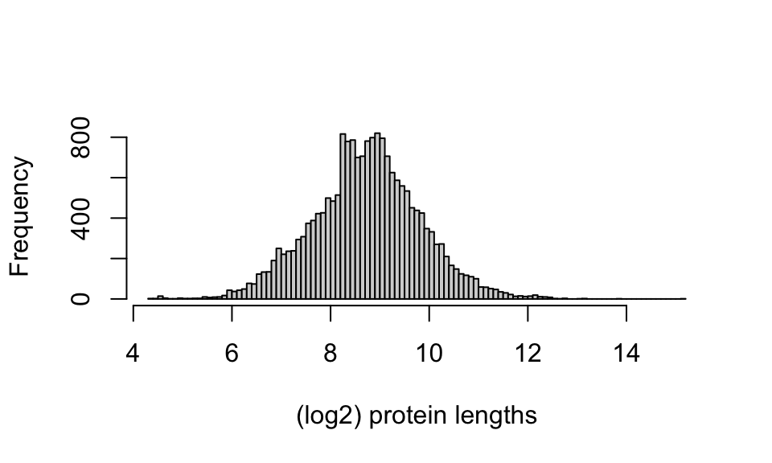

```r
# histogram of the distribution of protein length
# (the log2 is useful here to visualize the distribution better)
hist(log2(width(aa)), 100, main = "", xlab = "(log2) protein lengths" )
```

```r
# parse strings
library(stringr)
nms <- str_split(names(aa), "\\.", simplify = TRUE)
#or
nms <- str_replace(names(aa), "9606.", "")

# count number of Ps
numps <- vcountPattern(pattern = "P", aa)


# make data.frame
df <- data.frame(protein_id = nms, #or nms[,1]
                 width = width(aa),
                 prolines = numps)
head(df)
```

```
##        protein_id width prolines
## 1 ENSP00000000233   180        4
## 2 ENSP00000000412   277        8
## 3 ENSP00000001008   459       16
## 4 ENSP00000001146   512       22
## 5 ENSP00000002125   441       25
## 6 ENSP00000002165   467       32
```

```r
# write to file
write.table(df, "human_protein_lengths.txt",
            sep = "\t", row.names = FALSE, quote = FALSE)
```

# Question 3

Repeat the following (von Mering) Python exercise using the string manipulation facilities in R:

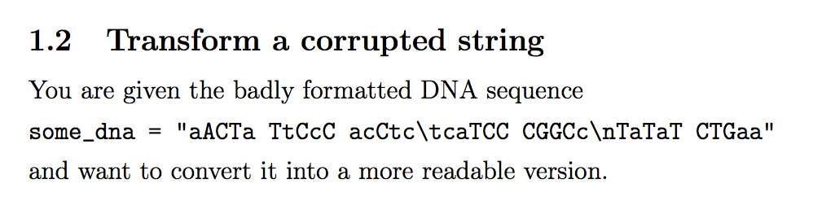

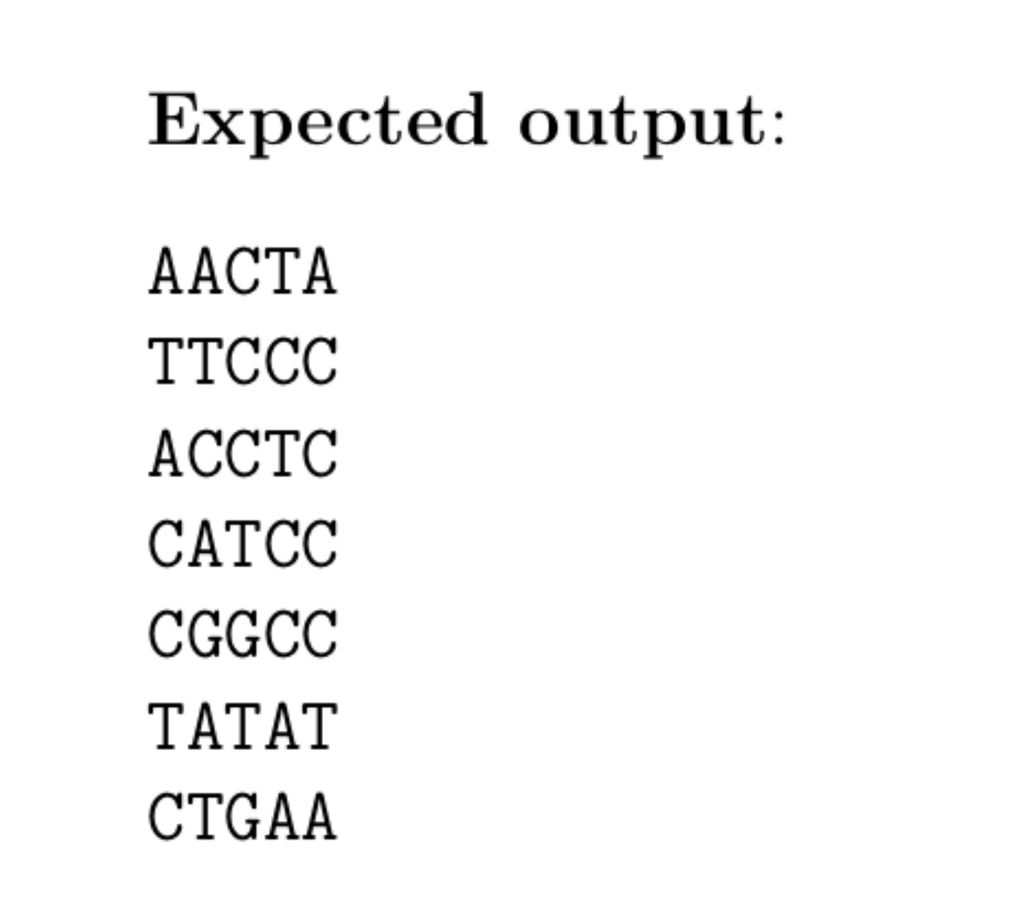

*Hints:*

- You could use `str_replace_all` and `str_to_upper` in the `stringr` package. Or, something else!
- You can return your result as a vector, and use `cat()` to show expected output on screen.
- Use the code below to define the corrupted string:

```r
dna <- "aACTa TtCcC acCtc\tcaTCC CGGCc\nTaTaT CTGaa"
```

The output can look like this:

```r
#Option 1: replace one by one:
dna <- str_to_upper(dna)
dna <- str_replace_all(dna, "\t", "\n")
dna <- str_replace_all(dna, " ", "\n")
cat(dna)
```

```
## AACTA
## TTCCC
## ACCTC
## CATCC
## CGGCC
## TATAT
## CTGAA
```

```r
# Option 1: replace all together with regex
dna <- str_to_upper(dna)
dna <- str_replace_all(dna, "[ |\t]", "\n")
cat(dna)
```

```
## AACTA
## TTCCC
## ACCTC
## CATCC
## CGGCC
## TATAT
## CTGAA
```

```r
# Option 2: use toupper(), replace multiple things at once
dna <- gsub("[ |\t]","\n",toupper(dna))
cat(dna,"\n")
```

```
## AACTA
## TTCCC
## ACCTC
## CATCC
## CGGCC
## TATAT
## CTGAA
```

# Question 4

Next, we want to use R to do a calculation and automate a small task (e.g., repeat the calculation for multiple input files). We have data (gene expression counts based on RNA-seq) that comes to us as 7 different files for an experiment comparing the transcriptional changes between S2 cells that were untreated (4 samples) versus knocking down a splicing factor (3 samples) called pasilla or CG8144 (*Drosophila*).

The files are:

```
S2_DRSC_CG8144_RNAi-1.count
S2_DRSC_CG8144_RNAi-3.count
S2_DRSC_CG8144_RNAi-4.count
S2_DRSC_Untreated-1.count
S2_DRSC_Untreated-3.count
S2_DRSC_Untreated-4.count
S2_DRSC_Untreated-6.count
```

Each file contains 2 columns (gene identifier, count):

```
FBgn0000003 0
FBgn0000008 115
FBgn0000014 0
```

We want to perform the same operation on each file: count the number of genes with a count-per-million (CPM) `> 1`. CPM is calculated as `CPM = 1e6 * count / sum(all counts)`, that is, the normalized count if the total sum was 1 million and is one way to report expression levels.  
Write R code to calculate the CPM and count the number of genes with `CPM > 1`. Return a vector of length 7 (i.e., one for each file). You can choose to use a for loop or lapply/sapply, as you wish.

*Notes:*

- Files will be made available either on Slack, OLAT or a web link.
- First, transfer the files over to your directory on renku (perhaps a directory called ‘data’ in a subfolder called ‘exercise1’).
- Use the following code to list all files, and then loop or apply on this vector

```r
fs <- list.files("../data",".count$", full.names = TRUE) #use the directory where you saved your files!
```

The output should look something like this:

```r
#Option with for loop
hcps <- rep(0,length(fs))
names(hcps) <- fs
for(i in 1:length(fs)){
  d <- read.table(fs[i])
  cpm <- 1e6 * d[,2] / sum(d[,2])
  hcps[i] <- sum(cpm > 1)
}

# Option 1 apply
hcps <- sapply(fs, function(u) {
  d <- read.table(u)
  sum((1e6 * d[,2] / sum(d[,2])) > 1)
  }
)

# Option 2: equivalent to above, easier to read
# a function to read file, calculate CPM, return # > min value
countHighCPM <- function(f, min = 1) {
  d <- read.table(f)
  cpm <- 1e6 * d[,2] / sum(d[,2])
  sum(cpm > min)
}

hcps <- sapply(fs, countHighCPM)
hcps
```

```
## ../data/S2_DRSC_CG8144_RNAi-1.count ../data/S2_DRSC_CG8144_RNAi-3.count
##                                7934                                7868
## ../data/S2_DRSC_CG8144_RNAi-4.count   ../data/S2_DRSC_Untreated-1.count
##                                7894                                7859
##   ../data/S2_DRSC_Untreated-3.count   ../data/S2_DRSC_Untreated-4.count
##                                7942                                7835
##   ../data/S2_DRSC_Untreated-6.count
##                                7786
```